# (first) eda (exploratory data analysis)

data was collected by querying linka's api (airelibre's backend)

in 1 hour windows

for a span of 5+ years, starting at `2020-11-01T00:00:00Z`

(you can go straight to the summary)

```python
import duckdb
import matplotlib.pyplot as plt
```

```python
from src.config import CONFIG

DB_PATH = "../" + CONFIG["paths"]["db_path"]
RAW_SCHEMA = 'raw'
RAW_TABLE = RAW_SCHEMA + '.readings'
```

```python
con = duckdb.connect(DB_PATH)
```

## data shape

```python
con.query(f"DESCRIBE {RAW_TABLE}")
```

```
┌─────────────┬───────────────────────────────────────────────────────────────────────────────────────────────────────────────────────────────────────────────────┬─────────┬─────────┬─────────┬─────────┐
│ column_name │                                                                    column_type                                                                    │  null   │   key   │ default │  extra  │
│   varchar   │                                                                      varchar                                                                      │ varchar │ varchar │ varchar │ varchar │
├─────────────┼───────────────────────────────────────────────────────────────────────────────────────────────────────────────────────────────────────────────────┼─────────┼─────────┼─────────┼─────────┤
│ start       │ TIMESTAMP                                                                                                                                         │ YES     │ NULL    │ NULL    │ NULL    │
│ end         │ TIMESTAMP                                                                                                                                         │ YES     │ NULL    │ NULL    │ NULL    │
│ data        │ STRUCT(sensor VARCHAR, "source" VARCHAR, description JSON, longitude DOUBLE, latitude DOUBLE, quality STRUCT(category VARCHAR, "index" BIGINT))[] │ YES     │ NULL    │ NULL    │ NULL    │
└─────────────┴───────────────────────────────────────────────────────────────────────────────────────────────────────────────────────────────────────────────────┴─────────┴─────────┴─────────┴─────────┘
```

```python
# let's first unnest the results
df = con.query(f"""
WITH unnested as (
    SELECT
        start,
        "end",
        UNNEST(data) AS item
    FROM {RAW_TABLE}
)
SELECT
    start,
    "end",
    item.*
FROM unnested
""").to_df()
```

```python
df.info()
```

```
<class 'pandas.DataFrame'>
RangeIndex: 859564 entries, 0 to 859563
Data columns (total 8 columns):
 #   Column       Non-Null Count   Dtype
---  ------       --------------   -----
 0   start        859564 non-null  datetime64[us]
 1   end          859564 non-null  datetime64[us]
 2   sensor       859564 non-null  str
 3   source       859564 non-null  str
 4   description  857653 non-null  str
 5   longitude    859564 non-null  float64
 6   latitude     859564 non-null  float64
 7   quality      859564 non-null  object
dtypes: datetime64[us](2), float64(2), object(1), str(3)
memory usage: 76.8+ MB
```

```python
# we still have a nested object (quality)...
df.iloc[0]["quality"]
# it has 2 components: category and index (the AQI)
```

```
{'category': 'Moderate', 'index': 66}
```

```python
df = con.query(f"""
WITH unnested as (
    SELECT
        start,
        "end",
        UNNEST(data) AS item
    FROM {RAW_TABLE}
)
SELECT
    start,
    "end",
    item.source AS "source",
    item.sensor AS sensor,
    item.description AS description,
    item.latitude
        AS latitude,
    item.longitude
        AS longitude,
    item.quality.category AS quality_category,
    CAST(item.quality.index AS INTEGER) AS quality_index
FROM unnested
""").to_df()
```

## quantitative values (stats)

```python
df[['quality_index', 'latitude', 'longitude', 'start', 'end']].describe()
```

|  | quality_index | latitude | longitude | start | end |
| --- | --- | --- | --- | --- | --- |
| count | 859564.000000 | 859564.000000 | 859564.000000 | 859564 | 859564 |
| mean | 41.637740 | -25.124857 | -57.720926 | 2023-11-24 11:45:47.137850 | 2023-11-24 12:45:47.121330 |
| min | 0.000000 | -57.632578 | -84.128731 | 2020-11-01 00:00:00 | 2020-11-01 01:00:00 |
| 25% | 10.000000 | -25.369802 | -57.610068 | 2022-09-27 15:45:00 | 2022-09-27 16:45:00 |
| 50% | 27.000000 | -25.313345 | -57.540101 | 2023-11-03 05:00:00 | 2023-11-03 06:00:00 |
| 75% | 58.000000 | -25.287000 | -57.476000 | 2025-02-04 16:00:00 | 2025-02-04 17:00:00 |
| max | 499.000000 | 90.000000 | 180.000000 | 2026-07-23 17:00:00 | 2026-07-23 18:00:00 |
| std | 44.087958 | 3.624065 | 2.760675 | NaN | NaN |

- datetimes: as expected
- (air) quality index (AQI):

  > values range from 0 to 499, so that's reasonable

  > average AQI is 41.6, which is in the (far-end) 'good' range

  > (see https://www.airnow.gov/aqi/aqi-basics/ for details)
- location (latitude, longitude):

  > sensors are [located](https://airelib.re/) within paraguayan territory, the majority being clustered around asuncion-paraguay (coordinates: [(-25.2800, -57.6344)](https://www.openstreetmap.org/?mlat=-25.284&mlon=-59.013#map=7/-25.284/-59.013))

  > the mean value is ...reasonable, outside of asuncion but close enough [-25.1248, -57.7209](https://www.openstreetmap.org/?#map=7/-25.125/-57.721))

  > most values appear to be in that vicinity... BUT max values are positive! better check that

  **note:** 4 decimal-digits precision suffices for our purposes (mapping a sensor location to a set of readings)

**why 4 decimal digits are enough?**

(latitude, longitude) coordinates we are using spherical coordinates: 2 angles (sexagesimal by convention) that let us map every point on (the surface of) a (3D) sphere

the sphere being the earth, with radius R = 6371 km

its circumference is then C =2*\pi*R ~= 40030 km

that's what 360 degrees of latitude cover: one earth circumference

(starting from the equator: increasing latitude takes you toward the north pole, decreasing to the south pole)

1 latitude degree -> 40030/360 = 111.2 km => 0.0001 lat deg -> 11 m

now the distance span by a longitude degree will depend on the latitude we are at: at zero latitude (equator) it's the earth radius, but for other values it is less than that: it's R*cos(lat)

# exploration-staging

let's better save those flatened results, to query them

```python
con.query(f"""
CREATE OR REPLACE SCHEMA eda;
CREATE OR REPLACE TABLE eda.unnested_raw_readings AS
WITH unnested as (
    SELECT
        start,
        "end",
        UNNEST(data) AS item
    FROM {RAW_TABLE}
)
SELECT
    start,
    "end",
    item.source AS "source",
    item.sensor AS sensor,
    item.description AS description,
    item.latitude
        AS latitude,
    item.longitude
        AS longitude,
    item.quality.category AS quality_category,
    CAST(item.quality.index AS INTEGER) AS quality_index
FROM unnested
""")
```

## sensor identification

the columns

- `sensor`
- `source`
- `description`

will identify the sensors

```python
con.query("SELECT DISTINCT sensor FROM eda.unnested_raw_readings")
# this is the sensor type (PM = particulate matter)
```

```
┌─────────┐
│ sensor  │
│ varchar │
├─────────┤
│ OPC_N2  │
│ ZH07    │
│ SPS30   │
│ tchx84  │
│ string  │
│ PMS7003 │
│ Ventura │
│ PMS5003 │
│ Dummy   │
│ PMS9103 │
│ test    │
└─────────┘
  11 rows
```

```python
con.query("SELECT DISTINCT source FROM eda.unnested_raw_readings")
# and this would correspond to the (unique?) identifier
```

```
┌───────────────┐
│    source     │
│    varchar    │
├───────────────┤
│ b1c6e7        │
│ 76c103        │
│ e48b00        │
│ 8eb9          │
│ 4e86          │
│ fiuna-05      │
│ fiuna-07      │
│ fiuna-08      │
│ 7cc20e        │
│ 75eab2        │
│   ·           │
│   ·           │
│   ·           │
│ a20d1c        │
│ 17a34d        │
│ 548e11        │
│ afd864        │
│ 13a1a8        │
│ d917b1        │
│ cf9574        │
│ Barcequillo 1 │
│ string        │
│ a005          │
└───────────────┘
     88 rows
   (20 shown)
```

```python
con.query("""
SELECT
    source,
    COUNT(DISTINCT sensor) sensor_type_count
FROM eda.unnested_raw_readings
GROUP BY source
ORDER BY 2 DESC
""")
# it's not unique...
# (only in a few cases there's more than one 'sensor' (type) for a given 'source' value)
```

```
┌───────────────┬───────────────────┐
│    source     │ sensor_type_count │
│    varchar    │       int64       │
├───────────────┼───────────────────┤
│ 8eb9          │                 2 │
│ 21e57d        │                 2 │
│ 41ce3d        │                 2 │
│ 1781ae        │                 1 │
│ ce9c38        │                 1 │
│ fiuna-08      │                 1 │
│ dacd0a        │                 1 │
│ 180667        │                 1 │
│ Lambare 1     │                 1 │
│ 179a3a        │                 1 │
│   ·           │                 · │
│   ·           │                 · │
│   ·           │                 · │
│ 766c66        │                 1 │
│ d917b1        │                 1 │
│ a005          │                 1 │
│ 548e11        │                 1 │
│ 991219        │                 1 │
│ Barcequillo 1 │                 1 │
│ cf9574        │                 1 │
│ string        │                 1 │
│ 17a34d        │                 1 │
│ ESP32         │                 1 │
└───────────────┴───────────────────┘
  88 rows (20 shown)      2 columns
```

```python
con.query("""
SELECT DISTINCT
    source,
    description,
    sensor
FROM eda.unnested_raw_readings
ORDER BY 1
""")
# descriptions indicate location (also testing purposes, in some cases)
# notice: some descriptions hint at sensors changing location throughout time
```

```
┌──────────┬─────────────────────────┬─────────┐
│  source  │       description       │ sensor  │
│ varchar  │          json           │ varchar │
├──────────┼─────────────────────────┼─────────┤
│ 13a1a8   │ "Central-Mariano"       │ PMS7003 │
│ 159eaf   │ "Capiatá-Rojas Caña"    │ PMS7003 │
│ 1781ae   │ "FCA-UNP, Sede Ayolas"  │ PMS7003 │
│ 179a3a   │ "Pilar"                 │ PMS7003 │
│ 179a3a   │ "PIL2- FCA-UNP"         │ PMS7003 │
│ 17a34d   │ "FCA - CAMPUS UNP"      │ PMS7003 │
│ 17a34d   │ "FCA-CAMPUS UNP"        │ PMS7003 │
│ 180667   │ "Pilar_2"               │ PMS7003 │
│ 2104a    │ "FP-UNA Pettirossi"     │ PMS7003 │
│ 2156df   │ "FP-UNA Pettirossi"     │ PMS9103 │
│   ·      │          ·              │   ·     │
│   ·      │          ·              │   ·     │
│   ·      │          ·              │   ·     │
│ fiuna-05 │ "FIUNA 05, Villa Morra" │ OPC_N2  │
│ fiuna-07 │ "FIUNA 07, San Roque"   │ OPC_N2  │
│ fiuna-08 │ "FIUNA 08, Centro"      │ OPC_N2  │
│ fiuna-09 │ "FIUNA 08, Mbocayaty"   │ OPC_N2  │
│ fiuna-09 │ "FIUNA 09, Mbocayaty"   │ OPC_N2  │
│ fiuna-10 │ "FIUNA 10, Residenta"   │ OPC_N2  │
│ fiuna-10 │ "FIUNA 08, Residenta"   │ OPC_N2  │
│ string   │ "string"                │ string  │
│ tchx84   │ NULL                    │ tchx84  │
│ test     │ "test"                  │ test    │
└──────────┴─────────────────────────┴─────────┘
  155 rows (20 shown)                3 columns
```

## sensor record/readings counts

```python
counts = con.query("""
SELECT
    source,
    sensor,
    COUNT(*) readings_count,
    ROUND(COUNT(*)/(24*365), 2) readings_count_to_years
FROM eda.unnested_raw_readings
GROUP BY source, sensor
ORDER BY 3 DESC
""")
counts
# (1 reading = 1 hour)
```

```
┌────────────────────┬─────────┬────────────────┬─────────────────────────┐
│       source       │ sensor  │ readings_count │ readings_count_to_years │
│      varchar       │ varchar │     int64      │         double          │
├────────────────────┼─────────┼────────────────┼─────────────────────────┤
│ 356690             │ PMS7003 │          46154 │                    5.27 │
│ 991219             │ PMS7003 │          37896 │                    4.33 │
│ 8eb9               │ PMS7003 │          36618 │                    4.18 │
│ 216b9a             │ PMS7003 │          35298 │                    4.03 │
│ 9cde79             │ PMS7003 │          32349 │                    3.69 │
│ d87553             │ PMS7003 │          31281 │                    3.57 │
│ 21d30a             │ PMS7003 │          30694 │                     3.5 │
│ d0caf2             │ PMS7003 │          28114 │                    3.21 │
│ dab551             │ PMS7003 │          27467 │                    3.14 │
│ 4e86               │ PMS7003 │          27414 │                    3.13 │
│  ·                 │   ·     │              · │                      ·  │
│  ·                 │   ·     │              · │                      ·  │
│  ·                 │   ·     │              · │                      ·  │
│ Barcequillo - test │ Dummy   │              3 │                     0.0 │
│ 180667             │ PMS7003 │              3 │                     0.0 │
│ 52634d             │ PMS9103 │              2 │                     0.0 │
│ 9ee8c3             │ PMS7003 │              2 │                     0.0 │
│ test               │ test    │              2 │                     0.0 │
│ a005               │ PMS7003 │              2 │                     0.0 │
│ string             │ string  │              1 │                     0.0 │
│ tchx84             │ tchx84  │              1 │                     0.0 │
│ 548e11             │ PMS7003 │              1 │                     0.0 │
│ dabcd3             │ PMS7003 │              1 │                     0.0 │
└────────────────────┴─────────┴────────────────┴─────────────────────────┘
  91 rows (20 shown)                                            4 columns
```

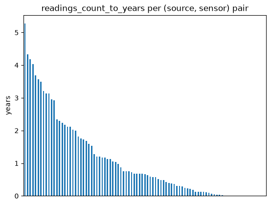

```python
_ = counts.df().plot.bar(y='readings_count_to_years', xticks=[], legend=None,
    title='readings_count_to_years per (source, sensor) pair', ylabel='years')
# just some ugly plots for now
```

## reading time-ranges

```python
q = con.query("""
SELECT
    source,
    sensor,
    COUNT(*) readings_count,
    MIN(start) min_start,
    MAX(d.end) max_end
FROM eda.unnested_raw_readings d
GROUP BY source, sensor
ORDER BY 3 DESC
""")
q
```

```
┌────────────────────┬─────────┬────────────────┬─────────────────────┬─────────────────────┐
│       source       │ sensor  │ readings_count │      min_start      │       max_end       │
│      varchar       │ varchar │     int64      │      timestamp      │      timestamp      │
├────────────────────┼─────────┼────────────────┼─────────────────────┼─────────────────────┤
│ 356690             │ PMS7003 │          46154 │ 2020-11-01 00:00:00 │ 2026-07-11 01:00:00 │
│ 991219             │ PMS7003 │          37896 │ 2022-02-05 17:00:00 │ 2026-07-23 18:00:00 │
│ 8eb9               │ PMS7003 │          36618 │ 2022-04-12 22:00:00 │ 2026-07-23 18:00:00 │
│ 216b9a             │ PMS7003 │          35298 │ 2020-11-20 18:00:00 │ 2025-08-31 11:00:00 │
│ 9cde79             │ PMS7003 │          32349 │ 2022-02-17 20:00:00 │ 2026-07-15 19:00:00 │
│ d87553             │ PMS7003 │          31281 │ 2022-04-22 23:00:00 │ 2026-07-23 15:00:00 │
│ 21d30a             │ PMS7003 │          30694 │ 2020-11-20 20:00:00 │ 2026-07-15 18:00:00 │
│ d0caf2             │ PMS7003 │          28114 │ 2021-09-03 23:00:00 │ 2025-07-19 14:00:00 │
│ dab551             │ PMS7003 │          27467 │ 2022-11-01 01:00:00 │ 2026-07-23 18:00:00 │
│ 4e86               │ PMS7003 │          27414 │ 2022-04-10 20:00:00 │ 2025-10-28 13:00:00 │
│  ·                 │    ·    │              · │          ·          │          ·          │
│  ·                 │    ·    │              · │          ·          │          ·          │
│  ·                 │    ·    │              · │          ·          │          ·          │
│ 180667             │ PMS7003 │              3 │ 2025-05-09 22:00:00 │ 2025-05-10 01:00:00 │
│ Barcequillo - test │ Dummy   │              3 │ 2025-07-01 10:00:00 │ 2025-07-01 14:00:00 │
│ test               │ test    │              2 │ 2020-12-04 15:00:00 │ 2021-10-04 22:00:00 │
│ a005               │ PMS7003 │              2 │ 2022-04-10 20:00:00 │ 2022-04-10 22:00:00 │
│ 52634d             │ PMS9103 │              2 │ 2023-12-13 18:00:00 │ 2025-02-09 17:00:00 │
│ 9ee8c3             │ PMS7003 │              2 │ 2024-12-04 23:00:00 │ 2024-12-05 01:00:00 │
│ dabcd3             │ PMS7003 │              1 │ 2024-11-30 21:00:00 │ 2024-11-30 22:00:00 │
│ string             │ string  │              1 │ 2021-10-05 03:00:00 │ 2021-10-05 04:00:00 │
│ tchx84             │ tchx84  │              1 │ 2020-11-20 17:00:00 │ 2020-11-20 18:00:00 │
│ 548e11             │ PMS7003 │              1 │ 2024-11-30 20:00:00 │ 2024-11-30 21:00:00 │
└────────────────────┴─────────┴────────────────┴─────────────────────┴─────────────────────┘
  91 rows (20 shown)                                                              5 columns
```

## AQI samples

Let's take a look at some data... from the sensors with the most data

```python
df = con.query("""
WITH best_sensors AS (
    SELECT
        source,
        sensor,
        COUNT(*) readings_count
    FROM eda.unnested_raw_readings
    GROUP BY source, sensor
    ORDER BY 3 DESC
    LIMIT 3
)
SELECT
    source,
    sensor,
    start dt,
    quality_index aqi
FROM eda.unnested_raw_readings d
JOIN best_sensors USING (source, sensor)
ORDER BY 3
""").df()
```

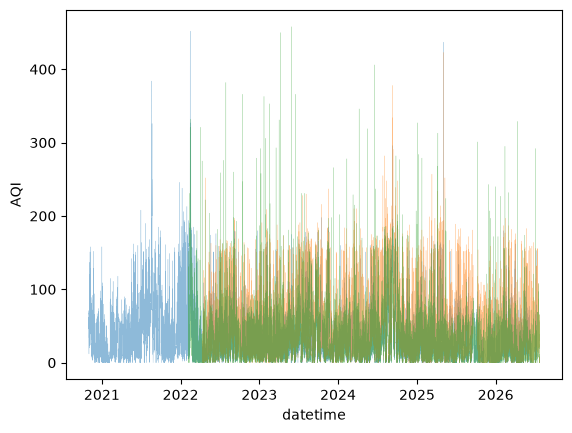

```python
for source, group in df.groupby('source'):
    plt.plot(group['dt'], group['aqi'], alpha=0.5, linewidth=0.2)
plt.xlabel('datetime')
plt.ylabel('AQI')
plt.show()
```

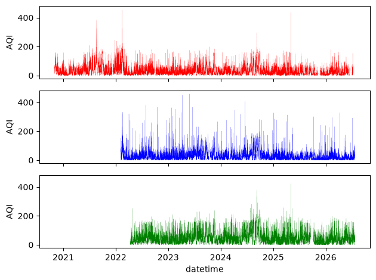

```python
sources = df['source'].unique()
fig, axes = plt.subplots(
    len(sources), 1,
    sharex=True, sharey=True)

colors = ['red', 'blue', 'green']
for i, (ax, source) in enumerate(zip(axes, sources, strict=False)):
    data = df[df['source'] == source]
    ax.plot(data['dt'], data['aqi'], color=colors[i], linewidth=0.1)
    #ax.set_title(source)
    ax.set_ylabel('AQI')

axes[-1].set_xlabel('datetime')
plt.tight_layout()
plt.show()
```

Alright! one can see some little gaps here and there but nice coverage overall

Some of those coordinated high-AQI times may be related to real events. We'll see...

## sensor locations

```python
locations = con.query("""
SELECT DISTINCT
    source,
    sensor,
    ROUND(latitude, 4) lat,
    ROUND(longitude, 4) lon
FROM eda.unnested_raw_readings
ORDER BY lat, lon, source
""")
locations
```

```
┌────────────────────┬─────────┬──────────┬──────────┐
│       source       │ sensor  │   lat    │   lon    │
│      varchar       │ varchar │  double  │  double  │
├────────────────────┼─────────┼──────────┼──────────┤
│ 23fbe1             │ PMS5003 │ -57.6326 │ -25.3058 │
│ 23fbe1             │ PMS5003 │ -57.6325 │ -25.3057 │
│ Barcequillo - test │ Dummy   │ -57.5401 │ -25.3633 │
│ Barcequillo 1      │ SPS30   │ -57.5401 │ -25.3633 │
│ 41ce3d             │ PMS7003 │ -57.5146 │ -25.2658 │
│ dc8ba1             │ PMS9103 │ -57.5134 │ -25.3354 │
│ 98ce61             │ PMS7003 │    -57.0 │    -25.0 │
│ 1781ae             │ PMS7003 │  -27.387 │ -56.8202 │
│ 219aa2             │ PMS7003 │  -27.374 │ -55.8449 │
│ 453637             │ PMS7003 │ -27.3633 │ -56.8507 │
│   ·                │    ·    │     ·    │     ·    │
│   ·                │    ·    │     ·    │     ·    │
│   ·                │    ·    │     ·    │     ·    │
│ 7c4984             │ PMS7003 │ -24.9812 │ -57.5573 │
│ 216b9a             │ PMS7003 │ -23.4425 │ -58.4438 │
│ 3d6c59             │ PMS7003 │ -23.4425 │ -58.4438 │
│ b1c198             │ PMS7003 │ -22.0547 │ -59.8476 │
│ tchx84             │ tchx84  │      0.0 │      0.0 │
│ test               │ test    │      0.0 │      0.0 │
│ d7410d             │ PMS7003 │   9.9683 │ -84.1287 │
│ d7410d             │ PMS7003 │  10.0179 │ -84.1049 │
│ string             │ string  │     90.0 │    180.0 │
│ test               │ test    │     90.0 │    180.0 │
└────────────────────┴─────────┴──────────┴──────────┘
  151 rows (20 shown)                      4 columns
```

intesting. some (source, sensor) pairs appear more than once, with different locations

(that'd be the same sensor either moving to another area or just updating coordinates)

let's try reducing the precision for the above query (0.01 deg -> 1 km)

```python
locations = con.query("""
SELECT DISTINCT
    source,
    sensor,
    ROUND(latitude, 2) lat,
    ROUND(longitude, 2) lon
FROM eda.unnested_raw_readings
ORDER BY lat, lon, source
""")
locations
# that got rid of some rows
```

```
┌────────────────────┬─────────┬────────┬────────┐
│       source       │ sensor  │  lat   │  lon   │
│      varchar       │ varchar │ double │ double │
├────────────────────┼─────────┼────────┼────────┤
│ 23fbe1             │ PMS5003 │ -57.63 │ -25.31 │
│ Barcequillo - test │ Dummy   │ -57.54 │ -25.36 │
│ Barcequillo 1      │ SPS30   │ -57.54 │ -25.36 │
│ dc8ba1             │ PMS9103 │ -57.51 │ -25.34 │
│ 41ce3d             │ PMS7003 │ -57.51 │ -25.27 │
│ 98ce61             │ PMS7003 │  -57.0 │  -25.0 │
│ 1781ae             │ PMS7003 │ -27.39 │ -56.82 │
│ 219aa2             │ PMS7003 │ -27.37 │ -55.84 │
│ 453637             │ PMS7003 │ -27.36 │ -56.85 │
│ 766c66             │ PMS7003 │ -27.35 │ -55.87 │
│   ·                │    ·    │    ·   │    ·   │
│   ·                │    ·    │    ·   │    ·   │
│   ·                │    ·    │    ·   │    ·   │
│ 7c4984             │ PMS7003 │ -24.98 │ -57.56 │
│ 216b9a             │ PMS7003 │ -23.44 │ -58.44 │
│ 3d6c59             │ PMS7003 │ -23.44 │ -58.44 │
│ b1c198             │ PMS7003 │ -22.05 │ -59.85 │
│ tchx84             │ tchx84  │    0.0 │    0.0 │
│ test               │ test    │    0.0 │    0.0 │
│ d7410d             │ PMS7003 │   9.97 │ -84.13 │
│ d7410d             │ PMS7003 │  10.02 │  -84.1 │
│ string             │ string  │   90.0 │  180.0 │
│ test               │ test    │   90.0 │  180.0 │
└────────────────────┴─────────┴────────┴────────┘
  136 rows (20 shown)                  4 columns
```

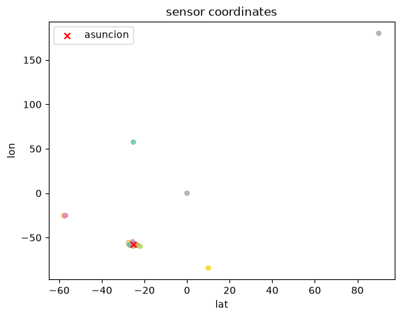

```python
ldf = locations.df()

ax = ldf.plot.scatter(x='lat', y='lon', c=ldf['source'].astype('category').cat.codes,
    cmap='Set2', colorbar=False, alpha=0.8, title='sensor coordinates')

ax.scatter(-25.28000, -57.63444, marker='x', color='red', zorder=5, label='asuncion')

_ = ax.legend()
```

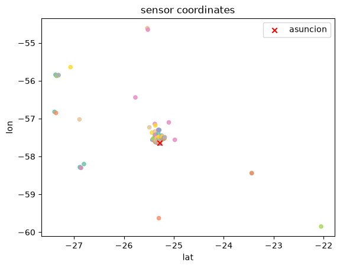

```python
ldf = locations.df()
fldf = ldf[(-30<ldf.lat)&(ldf.lat<-20)&(-65<ldf.lon)&(ldf.lon<-40)] # filtered

ax = fldf.plot.scatter(x='lat', y='lon',
    c=fldf['source'].astype('category').cat.codes,
    cmap='Set2', colorbar=False, alpha=0.8, title='sensor coordinates')

ax.scatter(-25.28000, -57.63444, marker='x', color='red', zorder=5, label='asuncion')

_ = ax.legend()

# yes this could have been a better plot... we'll do that later too
```

```python
con.query("""
SELECT DISTINCT
    source,
    sensor,
    description,
    ROUND(latitude, 2) lat,
    ROUND(longitude, 2) lon
FROM eda.unnested_raw_readings
WHERE lat>=0 OR lon>=0
ORDER BY lat, lon, source
""")
```

```
┌─────────┬─────────┬────────────────────┬────────┬────────┐
│ source  │ sensor  │    description     │  lat   │  lon   │
│ varchar │ varchar │        json        │ double │ double │
├─────────┼─────────┼────────────────────┼────────┼────────┤
│ 13a1a8  │ PMS7003 │ "Central-Mariano"  │ -25.21 │  57.54 │
│ tchx84  │ tchx84  │ NULL               │    0.0 │    0.0 │
│ test    │ test    │ "test"             │    0.0 │    0.0 │
│ d7410d  │ PMS7003 │ "Bambu - Prueba"   │   9.97 │ -84.13 │
│ d7410d  │ PMS7003 │ "Heredia - Prueba" │  10.02 │  -84.1 │
│ string  │ string  │ "string"           │   90.0 │  180.0 │
│ test    │ test    │ "test"             │   90.0 │  180.0 │
└─────────┴─────────┴────────────────────┴────────┴────────┘
```

those are (source, sensor) pairs with weird locations most of them describe testing purposes

```python
con.query("""
SELECT DISTINCT
    source,
    sensor,
    COUNT(DISTINCT ROUND(latitude, 2)) lat_count,
    COUNT(DISTINCT ROUND(longitude, 2)) lon_count
FROM eda.unnested_raw_readings
GROUP BY source, sensor
ORDER BY lat_count DESC, lon_count DESC
""")
```

```
┌──────────┬─────────┬───────────┬───────────┐
│  source  │ sensor  │ lat_count │ lon_count │
│ varchar  │ varchar │   int64   │   int64   │
├──────────┼─────────┼───────────┼───────────┤
│ b27800   │ PMS7003 │         5 │         3 │
│ 219aa2   │ PMS7003 │         4 │         5 │
│ 3d6c59   │ PMS7003 │         4 │         4 │
│ 453637   │ PMS7003 │         3 │         4 │
│ d7410d   │ PMS7003 │         3 │         3 │
│ 98ce61   │ PMS7003 │         3 │         3 │
│ e48dde   │ PMS7003 │         3 │         3 │
│ 76c103   │ PMS7003 │         3 │         2 │
│ 9051     │ PMS7003 │         2 │         2 │
│ 4e86     │ PMS7003 │         2 │         2 │
│  ·       │    ·    │         · │         · │
│  ·       │    ·    │         · │         · │
│  ·       │    ·    │         · │         · │
│ 991219   │ PMS7003 │         1 │         1 │
│ 8eb9     │ Ventura │         1 │         1 │
│ ESP32    │ PMS7003 │         1 │         1 │
│ 8f45d2   │ PMS7003 │         1 │         1 │
│ 21e57d   │ PMS7003 │         1 │         1 │
│ b773ec   │ PMS7003 │         1 │         1 │
│ d0caf2   │ PMS7003 │         1 │         1 │
│ db013e   │ PMS7003 │         1 │         1 │
│ fiuna-07 │ OPC_N2  │         1 │         1 │
│ 180667   │ PMS7003 │         1 │         1 │
└──────────┴─────────┴───────────┴───────────┘
  91 rows (20 shown)               4 columns
```

confirmed: some sensors move, even when reducing precision significantly (to 2 digits)

that should be taken into account

```python
con.query("""
SELECT DISTINCT
    source,
    sensor,
    COUNT(DISTINCT ROUND(latitude, 2)) lat_count,
    COUNT(DISTINCT ROUND(longitude, 2)) lon_count
FROM eda.unnested_raw_readings
GROUP BY source, sensor
HAVING lon_count>1 OR lon_count>1
ORDER BY lat_count DESC, lon_count DESC
""")
```

```
┌───────────────┬─────────┬───────────┬───────────┐
│    source     │ sensor  │ lat_count │ lon_count │
│    varchar    │ varchar │   int64   │   int64   │
├───────────────┼─────────┼───────────┼───────────┤
│ b27800        │ PMS7003 │         5 │         3 │
│ 219aa2        │ PMS7003 │         4 │         5 │
│ 3d6c59        │ PMS7003 │         4 │         4 │
│ 453637        │ PMS7003 │         3 │         4 │
│ e48dde        │ PMS7003 │         3 │         3 │
│ 98ce61        │ PMS7003 │         3 │         3 │
│ d7410d        │ PMS7003 │         3 │         3 │
│ 76c103        │ PMS7003 │         3 │         2 │
│ Barcequillo 1 │ SPS30   │         2 │         2 │
│ 23fbe1        │ PMS5003 │         2 │         2 │
│   ·           │    ·    │         · │         · │
│   ·           │    ·    │         · │         · │
│   ·           │    ·    │         · │         · │
│ 216b9a        │ PMS7003 │         2 │         2 │
│ 41ce3d        │ PMS7003 │         2 │         2 │
│ 21d30a        │ PMS7003 │         2 │         2 │
│ e48b00        │ PMS7003 │         2 │         2 │
│ 4e86          │ PMS7003 │         2 │         2 │
│ 29c607        │ PMS7003 │         2 │         2 │
│ dc8ba1        │ PMS9103 │         2 │         2 │
│ 179a3a        │ PMS7003 │         2 │         2 │
│ 76a20b        │ PMS7003 │         2 │         2 │
│ 13a1a8        │ PMS7003 │         1 │         2 │
└───────────────┴─────────┴───────────┴───────────┘
  30 rows (20 shown)                    4 columns
```

# summary

this was just a quick exploration of the dataset

by now it is still in a raw state

what we've seen:

- **AQI** (air quality index) values are within the expected range (0 to 500)
- given that **locations** are expected to be within paraguay, some location values are wrong (might be able to clean/fix some, discard the rest)
- sensor **lifespan** is highly variable (some have a very short lifespan and should be better discarded, but others might provide useful readings, even if they are no longer alive)

we didn't check coverage yet (the fraction of the lifespan with actual data), but we'll get to that

the **most important** thing to consider is the following:

## unit of analysis: `located_sensor`

while the fields `source` (hash identifier, in most cases), `sensor` (device type) and `description` (name) allow us do identify a measuring device,

what we care about is the AQI readings at a given location: the more sensors we have in an area, the better we can assess the air quality there (even if some malfunction)

so, a sensor that moves to a different location should be then taken as a different entity;

in other words, the unit of analysis will be a `located_sensor`, not just a device: same hardware at different locations will be treated as a distinct source

> `located_sensor` = (

> > `(source, sensor)` (sensor_hash, sensor_type),

> > `(latitude, longitude)` (location, with 4 decimal-digits precision for each coordinate)

> )

besides that, a description might change (we better take the latest value)

and a location might change by a few meters and correspond to the same `located_sensor` (so, we'll allow some jitter)